# Introduction

Paul Little

Last Updated: March 03, 2025

# Welcome

The sample code in this vignette is designed to show R users how to navigate UNMASC (Little et al., 2021) and its expected file types.

# Libraries

```r
library(smarter)
library(UNMASC)
library(data.table)
library(sqldf)
```

# Terminology

- MN = matched normal
- UMN = unmatched normal

# Simulate

The code below will generate

- 20 annotated VCFs, by default, representing 20 UMNs treated as MNs against a single tumor-only sample
- a target bed file
- centromere bed file
- chromosome sizes dictionary file

assuming that the tumor’s purity is 0.8 with a fixed seed.

```r
outdir = sprintf("%s/sim",getwd())

sim = UNMASC::gen_simulated_data(
  outdir = outdir,
  purity = purity,
  seed = 123)

print(sim)
```

```
## $vcf_files
##  [1] "C:/Users/Admin/Desktop/github/UNMASC/vignettes/sim/UMN_1.vcf"
##  [2] "C:/Users/Admin/Desktop/github/UNMASC/vignettes/sim/UMN_2.vcf"
##  [3] "C:/Users/Admin/Desktop/github/UNMASC/vignettes/sim/UMN_3.vcf"
##  [4] "C:/Users/Admin/Desktop/github/UNMASC/vignettes/sim/UMN_4.vcf"
##  [5] "C:/Users/Admin/Desktop/github/UNMASC/vignettes/sim/UMN_5.vcf"
##  [6] "C:/Users/Admin/Desktop/github/UNMASC/vignettes/sim/UMN_6.vcf"
##  [7] "C:/Users/Admin/Desktop/github/UNMASC/vignettes/sim/UMN_7.vcf"
##  [8] "C:/Users/Admin/Desktop/github/UNMASC/vignettes/sim/UMN_8.vcf"
##  [9] "C:/Users/Admin/Desktop/github/UNMASC/vignettes/sim/UMN_9.vcf"
## [10] "C:/Users/Admin/Desktop/github/UNMASC/vignettes/sim/UMN_10.vcf"
## [11] "C:/Users/Admin/Desktop/github/UNMASC/vignettes/sim/UMN_11.vcf"
## [12] "C:/Users/Admin/Desktop/github/UNMASC/vignettes/sim/UMN_12.vcf"
## [13] "C:/Users/Admin/Desktop/github/UNMASC/vignettes/sim/UMN_13.vcf"
## [14] "C:/Users/Admin/Desktop/github/UNMASC/vignettes/sim/UMN_14.vcf"
## [15] "C:/Users/Admin/Desktop/github/UNMASC/vignettes/sim/UMN_15.vcf"
## [16] "C:/Users/Admin/Desktop/github/UNMASC/vignettes/sim/UMN_16.vcf"
## [17] "C:/Users/Admin/Desktop/github/UNMASC/vignettes/sim/UMN_17.vcf"
## [18] "C:/Users/Admin/Desktop/github/UNMASC/vignettes/sim/UMN_18.vcf"
## [19] "C:/Users/Admin/Desktop/github/UNMASC/vignettes/sim/UMN_19.vcf"
## [20] "C:/Users/Admin/Desktop/github/UNMASC/vignettes/sim/UMN_20.vcf"
##
## $bed_regions
## [1] "C:/Users/Admin/Desktop/github/UNMASC/vignettes/sim/target.bed"
##
## $bed_centromere
## [1] "C:/Users/Admin/Desktop/github/UNMASC/vignettes/sim/hg19_centromeres.bed"
##
## $dict_chrom
## [1] "C:/Users/Admin/Desktop/github/UNMASC/vignettes/sim/hg19.dict"
##
## $gender
## [1] "FEMALE"
##
## $simulate
## [1] TRUE
```

## Single VCF

### Import

Code below imports a single vcf.

```r
vcf_fn = file.path(outdir,"UMN_1.vcf")
vcf = data.table::fread(vcf_fn,sep = "\t",data.table = FALSE)

dim(vcf)
```

```
## [1] 10000    11
```

```r
head(vcf,n = 3)
```

```
##   #CHROM    POS ID REF ALT QUAL FILTER
## 1      1  10232  .   A   T   50   PASS
## 2      1 574914  .   C   G   50   PASS
## 3      1 687827  .   A   G   50   PASS
##                                                                                                                                                                                                                                                                                                          …
## 1           ExAC_AF=0;1000gp3_AF=0;ExAC_ESP_AF_GLOBAL=0;gc_content=0.207;gene=Unknown;COSMIC_n_overlapping_mutations=0;HGNC_Ensembl_Gene_ID=ENST00000000000;variant_classification=Missense_Mutation;Ensembl_so_term=missense;ref_context=GAAGAAAGGCAGTGGTACCTT;EFF=NON_SYNONYMOUS_CODING(MODERATE|MISSEN…
## 2 ExAC_AF=0.2537;1000gp3_AF=0;ExAC_ESP_AF_GLOBAL=0.2537;gc_content=0.252;gene=Unknown;COSMIC_n_overlapping_mutations=0;HGNC_Ensembl_Gene_ID=ENST00000000000;variant_classification=Missense_Mutation;Ensembl_so_term=missense;ref_context=AATTGCTGTCCGTCATTGATA;EFF=NON_SYNONYMOUS_CODING(MODERATE|MISSEN…
## 3           ExAC_AF=0;1000gp3_AF=0;ExAC_ESP_AF_GLOBAL=0;gc_content=0.184;gene=Unknown;COSMIC_n_overlapping_mutations=0;HGNC_Ensembl_Gene_ID=ENST00000000000;variant_classification=Missense_Mutation;Ensembl_so_term=missense;ref_context=GGATCGCCGGATCTAGAGCCT;EFF=NON_SYNONYMOUS_CODING(MODERATE|MISSEN…
##     FORMAT          NORMAL           TUMOR
## 1 GT:AD:DP   ./.:7|424:431   ./.:0|466:466
## 2 GT:AD:DP ./.:211|297:508 ./.:155|148:303
## 3 GT:AD:DP ./.:118|105:223   ./.:301|0:301
```

### Wrangle

Remove some initial fields, order contigs with `ChrNum` derived field.

```r
# Ignore annotation
vcf = smarter::smart_rmcols(vcf,"INFO")

smart_table(vcf[["#CHROM"]])
```

```
##
##   1  10  11  12  13  14  15  16  17  18  19   2  20  21  22   3   4   5   6   7
## 784 427 381 402 395 344 359 331 316 309 317 688 279 263 264 660 620 589 515 559
##   8   9   X
## 498 463 237
```

```r
# For ordering contigs
vcf$ChrNum = ifelse(
  vcf[["#CHROM"]] == "X",23,
  ifelse(vcf[["#CHROM"]] == "Y",24,
    vcf[["#CHROM"]]))
vcf$ChrNum = as.integer(vcf$ChrNum)
```

### Read counts and VAF

Extracts tumor and normal read counts.

```r
vcf$nAD = NA
vcf$nRD = NA
vcf$tAD = NA
vcf$tRD = NA

vcf[,c("nAD","nRD")] = t(sapply(vcf$NORMAL,function(xx){
  xx = strsplit(xx,":")[[1]][2]
  xx = strsplit(xx,"[|]")[[1]]
  xx
},USE.NAMES = FALSE))

vcf[,c("tAD","tRD")] = t(sapply(vcf$TUMOR,function(xx){
  xx = strsplit(xx,":")[[1]][2]
  xx = strsplit(xx,"[|]")[[1]]
  xx
},USE.NAMES = FALSE))

# Rm NORMAL/TUMOR fields
vcf = smarter::smart_rmcols(vcf,c("TUMOR","NORMAL"))

# Set field types
for(nm in c("nAD","nRD","tAD","tRD")){
  vcf[,nm] = as.integer(vcf[,nm])
}

# Derive VAF and depth
vcf = smarter::smart_rmcols(vcf,
  c("nDP","tDP","nVAF","tVAF","ncex","tcex"))

vcf = sqldf("
  select
    vcf.*,
    nAD + nRD as nDP,
    tAD + tRD as tDP,
    1.0 * nAD / (nAD + nRD) as nVAF,
    1.0 * tAD / (tAD + tRD) as tVAF,
    0.5 * log10(nAD + nRD) as ncex,
    0.5 * log10(tAD + tRD) as tcex
  from
    vcf
  order by
    ChrNum,
    POS
")
head(vcf,n = 3)
```

```
##   #CHROM    POS ID REF ALT QUAL FILTER   FORMAT ChrNum nAD nRD tAD tRD nDP tDP
## 1      1  10232  .   A   T   50   PASS GT:AD:DP      1   7 424   0 466 431 466
## 2      1 574914  .   C   G   50   PASS GT:AD:DP      1 211 297 155 148 508 303
## 3      1 687827  .   A   G   50   PASS GT:AD:DP      1 118 105 301   0 223 301
##        nVAF      tVAF     ncex     tcex
## 1 0.0162413 0.0000000 1.317239 1.334193
## 2 0.4153543 0.5115512 1.352932 1.240721
## 3 0.5291480 1.0000000 1.174152 1.239283
```

```r
# Contigs, Positions
sqldf("
  select
    [#CHROM],
    count([#CHROM]) as num_loci,
    min(POS) as Min_Pos,
    max(POS) as Max_Pos
  from
    vcf
  group by
    ChrNum
")
```

```
##    #CHROM num_loci Min_Pos   Max_Pos
## 1       1      784   10232 247845846
## 2       2      688   98779 242779859
## 3       3      660   14646 197499299
## 4       4      620   92679 190989178
## 5       5      589  281037 180435750
## 6       6      515  719582 169516424
## 7       7      559  532764 158785997
## 8       8      498    2790 145908934
## 9       9      463   26844 141098231
## 10     10      427  590710 135254749
## 11     11      381  322821 134483396
## 12     12      402  430128 133198464
## 13     13      395  123914 115100571
## 14     14      344  196728 107236293
## 15     15      359   18968 102462290
## 16     16      331  104126  89907229
## 17     17      316  234615  81012569
## 18     18      309   57608  78050393
## 19     19      317   39932  59073770
## 20     20      279   85473  62440462
## 21     21      263  546697  47900410
## 22     22      264  466750  51134036
## 23      X      237   58568 153726212
```

### Visualize

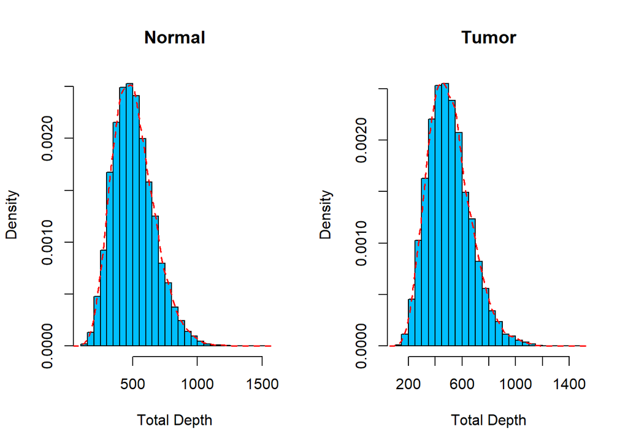

```r
par(mfrow = c(1,2))
smart_hist(vcf$nDP,breaks = 40,xlab = "Total Depth",main = "Normal")
smart_hist(vcf$tDP,breaks = 40,xlab = "Total Depth",main = "Tumor")
```

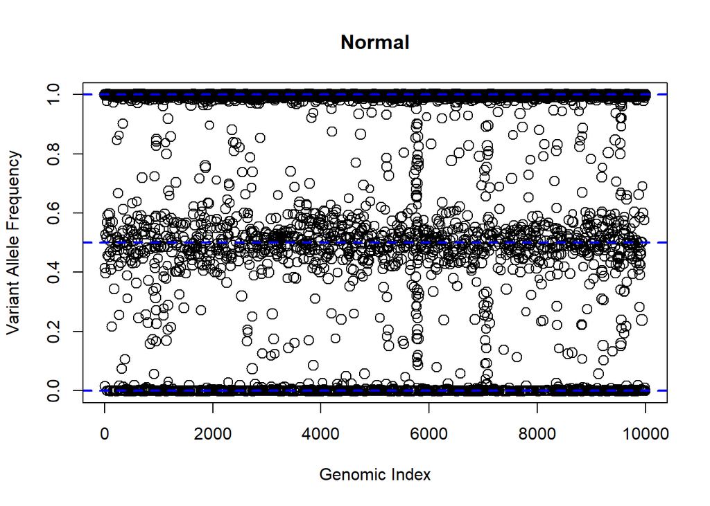

```r
plot(vcf$nVAF,
  main = "Normal",
  xlab = "Genomic Index",
  ylab = "Variant Allele Frequency",
  cex = vcf$ncex)
abline(h = c(0,0.5,1),lty = 2,lwd = 2,col = "blue")
```

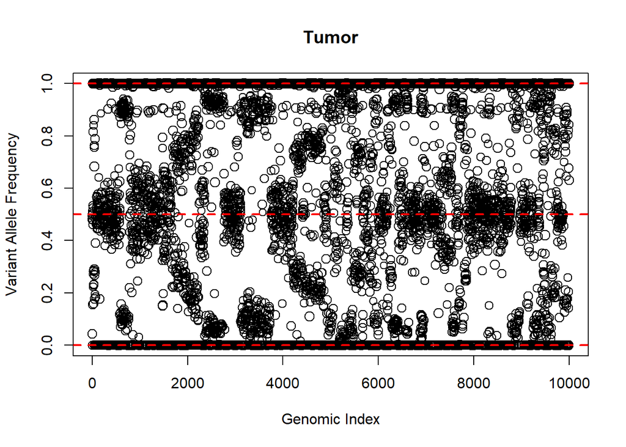

```r
plot(vcf$tVAF,
  main = "Tumor",
  xlab = "Genomic Index",
  ylab = "Variant Allele Frequency",
  cex = vcf$tcex)
abline(h = c(0,0.5,1),lty = 2,lwd = 2,col = "red")
```

## Tumor-only Annotation Workflow

The function `UNMASC::run_UNMASC()` requires a R data.frame with pre-set field names and data types, multiple file paths, and a few hyper parameters. With our simulated data set, we’ll import everything, extract necessary fields and run the full workflow.

### Import

```r
fvcf = c()
all_fns = list.files(outdir,pattern = "UMN_")
all_fns = all_fns[grepl(".vcf$",all_fns)]
for(fn in all_fns){
  message(".",appendLF = FALSE)
  vcf_fn = file.path(outdir,fn)
  nm = gsub(".vcf","",fn)
  vcf = data.table::fread(vcf_fn,sep = "\t",data.table = FALSE)

  # ID per UMN
  vcf$STUDYNUMBER = nm

  fvcf = rbind(fvcf,vcf)
}
```

```
## ....................
```

```r
dim(fvcf)
```

```
## [1] 200000     12
```

```r
smart_table(fvcf$STUDYNUMBER)
```

```
##
##  UMN_1 UMN_10 UMN_11 UMN_12 UMN_13 UMN_14 UMN_15 UMN_16 UMN_17 UMN_18 UMN_19
##  10000  10000  10000  10000  10000  10000  10000  10000  10000  10000  10000
##  UMN_2 UMN_20  UMN_3  UMN_4  UMN_5  UMN_6  UMN_7  UMN_8  UMN_9
##  10000  10000  10000  10000  10000  10000  10000  10000  10000
```

In a real data analysis, one might have multiple raw VCF files and a separate annotation file similar to the outputs from `../workflow/tumor_only.sh` through the provided bash function `TO_workflow()`. The user can perform a merge or SQL join between the raw VCF data.frame and annotation data.frame and pass the resulting data.frame into `UNMASC::run_UNMASC()`. Alternatively, the user can use `UNMASC::prep_UNMASC_VCF()` to parse the annotations, read counts and generate the required UNMASC input vcf R data.frame.

### Parse

```r
fin_vcf = sqldf("
  select
    [#CHROM] as Chr
  from
    fvcf
")
```

Let us isolate unique loci and parse annotations.

```r
anno = sqldf("
  select distinct
    [#CHROM],
    POS,
    REF,
    ALT,
    INFO
  from
    fvcf
")

dim(anno)
```

[output not shown]

### Execute

```r
UNMASC::run_UNMASC(
  outdir = outdir,
  vcf = fvcf,
  tumorID = "sim")
```

# References

Little, P., Jo, H., Hoyle, A., Mazul, A., Zhao, X., Salazar, A. H., Farquhar, D., Sheth, S., Masood, M., Hayward, M. C., Parker, J. S., Hoadley, K. A., Zevallos, J., & Hayes, D. N. (2021). UNMASC: Tumor-only variant calling with unmatched normal controls. *NAR Cancer*, *3*(4), zcab040.